# The Gender Pay Gap in UK Universities

Group 1 - Ankit Ray, Nitin Mathew, Sharan Pullabhatla, Vyshnav Varma

31/Oct/2022

# 1 Changes in Gender Pay Gap for the period 2017-22

> While we see improvements over a 5 year period, there continues to be disparity in pay, more so for universities established prior to 1992

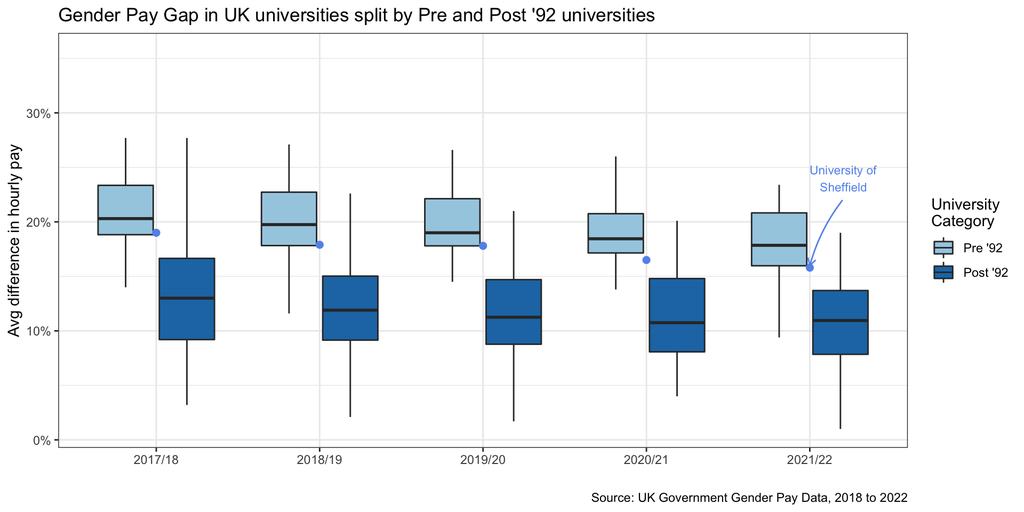

Figure 1

The data for Figure 1 is as per the **DiffMeanHourlyPercent** column from the published reports. This column represents the **Mean % difference between male and female hourly pay (negative = women’s mean hourly pay is higher)**. The outliers have been excluded from this plot.

Figure 1 shows how the official gender pay gap has changed from 2017/18 up until 2021/22. Looking at the interquartile ranges, we see them approximately between **9% and 23%** for the first period and improving slightly to around **8% and 21%** for the last fully published period.

Additionally, we do see a noticeable difference in the gap when looking at the Pre and Post ’92 universities with the **Post ’92** universities performing better over these years.

Finally, looking at the **University of Sheffield**, we find it having slight improvements in line with other Pre ’92 universities while remaining at the lower end of the 1st quartile for this category of universities for the reported periods.

### 1.1 Number of submissions at a glance

Table 1 - Shows how many universities have submitted GPD data

| Year of Submission | Pre ’92 | Post ’92 |
| --- | --- | --- |
| 2017/18 | 36 | 59 |
| 2018/19 | 36 | 60 |
| 2019/20 | 36 | 56 |
| 2020/21 | 36 | 62 |
| 2021/22 | 36 | 62 |

To provide additional context to the graph in Figure 1, we have Table 1 above showing the number of universities which have submitted their GPD data for the 5 year period in scope of this report.

# Data Sources

- The primary data for the report is based on the UK Government’s official GPD data available from https://gender-pay-gap.service.gov.uk/viewing/download
- The universities have been identified using the data available at https://vle.shef.ac.uk/bbcswebdav/pid-6298247-dt-content-rid-45156957_1/xid-45156957_1